# Logistic Regression | Codethrough

PAF 512 - Advanced Regression

# What Will We Cover?

#### 1. Understanding the Problem: Binary Outcomes

- Why standard OLS struggles with binary dependent variables
- What we mean by “modeling probability”

#### 2. The Key Concepts: A Translation Guide

- The four languages of logistic regression: log odds, odds ratios, probabilities, and marginal effects
- Why we need to convert between them and when to use each

#### 3. The Policy Problem

- Research question: What predicts recidivism among released inmates?
- The North Carolina recidivism data

#### 5. The Linear Probability Model (LPM)

- Run OLS with a binary dependent variable
- Interpret coefficients as changes in probability
- Why robust standard errors are required
- The three limitations of the LPM

#### 6. The Logit Model

- Run `glm()` with `family = "binomial"`
- Compare LPM and logit side-by-side
- Why you cannot directly compare coefficients across models

#### 7. Interpreting Logit Results

- Transform coefficients into odds ratios
- Calculate predicted probabilities (by hand and with `predict()`)
- Compute discrete changes between scenarios
- Plot the S-curve

#### 8. Marginal Effects

- Average Marginal Effects (AME)
- Marginal effects at specific values
- Why the same change in X produces different effects at different starting points

#### 9. Summary and Lab Workflow

- The complete logistic regression workflow
- Key takeaways

**Instructor’s Note: Variable Scaling in Your Lab**

Recall our Fixed Effects lab where beer taxes were our independent variable and we had to divide the coefficient by $100$ to express the effect as a $1$ percentage point increase? Your logistic regression lab has the same issue, but with **three** independent variables — Democrats, Evangelicals, and Catholics — all stored as proportions in decimal form (e.g., $0.26$ meaning $26\%$). In decimal form, a “1-unit increase” means going from $0\%$ to $100\%$, which is neither realistic nor meaningful.

Rather than have you manually scale three separate coefficients every time you compute odds ratios, predicted probabilities, or marginal effects, we pre-scaled those columns for you by multiplying by $100$. The `_s` variables (e.g., `Democrats_s`, `Evangelics_s`, `Catholics_s`) now range from $0$ to $100$, so a 1-unit increase already represents a $1$ percentage point change. Be sure to use the `_s` columns — not the originals.

# Understanding the Problem

## When the Outcome Is Yes or No

Throughout this course, our outcome variables have been continuous: number of passengers, wages, crime rates, test scores. OLS regression handles these well because the outcome can take any value along a continuous scale.

But many important questions in policy and program evaluation involve binary outcomes:

- Did the individual recidivate (return to prison) or not?
- Did the state adopt a policy or not?
- Did the student graduate or not?
- Did the patient recover or not?

These outcomes can only be $0$ or $1$. We are no longer predicting a value on a continuous scale; we are predicting the **probability** that the event occurs. This fundamental difference is what motivates everything we will cover in this codethrough.

## The Core Challenge

When the outcome is binary, we want our model to tell us: *“Given these characteristics, what is the probability that Y = 1?”* Probabilities, by definition, must be between $0$ and $1$. A probability of $-0.15$ or $1.30$ is nonsense.

OLS doesn’t know this. It fits a straight line through the data, and that line can easily extend below $0$ or above $1$ at extreme values of the independent variables. This is one of three key problems we will address.

We have two options for modeling binary outcomes: the **Linear Probability Model (LPM)**, which uses OLS and lives with its limitations, and the **Logit Model**, which uses a different estimation technique to constrain predictions between $0$ and $1$. We will build both, compare them, and learn how to interpret each.

# The Key Concepts: A Translation Guide

Before we touch any data, we need to understand the four different “languages” that logistic regression uses to express the same underlying relationship. This section is critical because the logit model estimates coefficients in one language (log odds), but we interpret results in others (odds ratios, probabilities, marginal effects). If you confuse them, your interpretation will be wrong.

## The Four Languages

Think of it like currency conversion. The underlying value is the same, but it is expressed differently depending on which “currency” you use:

| Language | Scale | Range | Interpretation |
| --- | --- | --- | --- |
| **Log Odds** | Continuous, symmetric | $-\infty$ to $+\infty$ | Raw coefficients from `glm()`. A 1-unit increase in X changes the log odds by $\beta$. Not intuitive. |
| **Odds Ratio** | Multiplicative | $0$ to $+\infty$ | Obtained via `exp(`$\beta$`)`. A 1-unit increase in X multiplies the odds by this factor. Below $1$ = decrease; above $1$ = increase. |
| **Probability** | Bounded | $0$ to $1$ | The actual likelihood of the event. This is what we ultimately care about, but it depends on the values of ALL variables. |
| **Marginal Effect** | Change in probability | Varies | How much the probability changes for a 1-unit increase in X, at a specific point. Similar to LPM coefficients but not constant. |

## A Worked Example: Converting Between All Four

Let’s say we have a logit model predicting whether a released inmate is rearrested ($Y = 1$), and one of the coefficients is $\beta_{drugs} = 0.693$ for a binary variable indicating prior drug use. Let’s convert this through all four languages.

### Step 1: Log Odds (Raw Coefficient)

The coefficient $0.693$ means having a drug history increases the **log odds** of rearrest by $0.693$ units. This is mathematically precise but not intuitive. Nobody thinks in log odds.

### Step 2: Log Odds > Odds Ratio

To convert log odds to an odds ratio, we exponentiate:

$$OR = e^{\beta} = e^{0.693} \approx
2.0$$

Interpretation: Individuals with a drug history have **$2$ times the odds** of being rearrested compared to those without a drug history, holding all else constant. Remember that an odds ratio is the likelihood of something happening vs. not happening. An odds ratio of $2.0$ (e.g., 4:2, 8:4, 2:1) means the odds are doubled.

Quick reference for interpreting odds ratios:

- $OR = 1.0$: No effect. The odds are unchanged.
- $OR > 1.0$: Positive effect. The odds increase. (e.g., $OR = 1.5$ means 50% higher odds)
- $OR < 1.0$: Negative effect. The odds decrease. (e.g., $OR = 0.75$ means 25% lower odds)

### Step 3: Log Odds > Probability

Here is where it gets important: **probabilities depend on the values of ALL variables in the model**, not just one. You cannot convert a single coefficient into a single probability. You must specify values for every variable first.

The conversion formula is:

$$P(Y=1) = \frac{1}{1 + e^{-(\beta_0 +
\beta_1 X_1 + \beta_2 X_2 + \cdots)}}$$

For example, suppose after plugging in the mean of every variable, the total linear combination is $-1.2$. Then:

$$P = \frac{1}{1 + e^{-(-1.2)}} =
\frac{1}{1 + e^{1.2}} = \frac{1}{1 + 3.32} \approx 0.231$$

The predicted probability of rearrest for this “average” individual is about $23.1\%$.

Now, suppose we change the drug history variable from $0$ to $1$ (adding $0.693$ to the linear combination), making it $-1.2 + 0.693 = -0.507$:

$$P = \frac{1}{1 + e^{-(-0.507)}} =
\frac{1}{1 + e^{0.507}} = \frac{1}{1 + 1.66} \approx 0.376$$

The probability increases from $23.1\%$ to $37.6\%$. The **discrete change** (the difference between the two probabilities) is $37.6 - 23.1 = 14.5$ percentage points.

### Step 4: Marginal Effect

The marginal effect captures the same idea as the discrete change but is calculated as the instantaneous rate of change at a specific point. The `margins()` function in R calculates this for us.

The key insight: **the marginal effect is not constant**. Because the logit model follows an S-curve, the same 1-unit change in X has a larger effect on probability near the middle of the curve (around $P = 0.5$) and a smaller effect near the tails (near $P = 0$ or $P = 1$).

**Instructor’s Note:**

This is the single most important conceptual difference between the LPM and the logit model. In the LPM, the effect of a 1-unit change in X on probability is **constant** - it’s just the coefficient. In the logit model, the effect **depends on where you are on the probability curve**. This is why we need tools like `predict()` and `margins()` to interpret logit results - we can’t just read the coefficient and be done.

## The Relationship Visualized

It helps to see how probabilities, odds ratios, and log odds relate to one another:

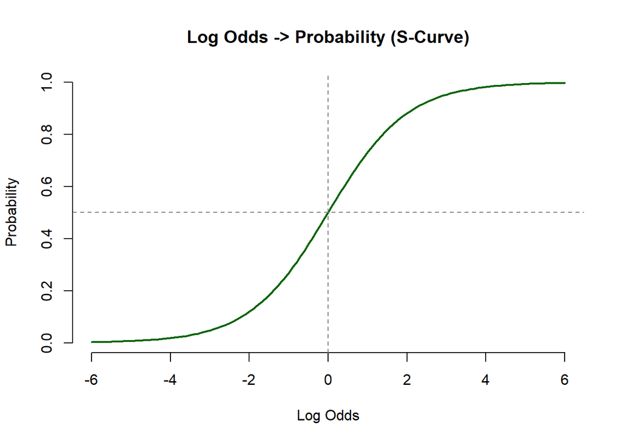

```r
# Probabilities
pr <- seq(0.01, 0.99, by = 0.01)


# Log Odds to Probability (the S-curve!)
log_odds_range <- seq(-6, 6, by = 0.1)
prob_from_logodds <- 1 / (1 + exp(-log_odds_range))
plot(log_odds_range, prob_from_logodds, type = "l", lwd = 2, col = "darkgreen",
     xlab = "Log Odds", ylab = "Probability",
     main = "Log Odds -> Probability (S-Curve)",
     bty = "n")
abline(h = 0.5, lty = 2, col = "gray50")
abline(v = 0, lty = 2, col = "gray50")
```

The **S-Curve**. This is the curve that the logit model fits to the data. Notice how the probability changes rapidly in the middle (around log odds = 0, probability = 0.5) but levels off at the extremes. This is why the marginal effect depends on where you are on the curve.

## What Do I Actually Need to Understand?

It can be confusing to keep these metrics straight, especially for those with minimal math backgrounds (this program doesn’t require heavy math prerequisites, so if you are feeling overwhelmed, you are okay!).

The bottom line is that the raw output of a `glm()` model is measured in **log odds**, which are not intuitive for humans to interpret. So, what are our options for translating this into something meaningful?

**1. Odds Ratios (Multiplier)** We can convert log odds into odds ratios by exponentiating the coefficient. However, on their own, odds ratios only tell half the story.

- An odds ratio tells you the *relative* multiple, but ignores the baseline.
- **Example:** Let’s say an odds ratio shows that a tutoring program triples your odds (3x) of getting into medical school. That sounds huge! But if your baseline odds of acceptance were 1 in 3,000, your new odds are 3 in 3,000. It is a massive relative jump, but the absolute change is negligible.

**2. Predicted Probabilities (Specific Situation)** We can use the probability formula or the `predict(..., type = "response")` function to calculate the actual probability of an event happening (bounded between 0 and 1). This is highly meaningful!

- To get a probability, we need specific *values* for every other variable in our model. If our medical school model includes age, income, and MCAT score, we have to plug in exact numbers for a hypothetical student. Because the logit model follows an S-curve, the impact of tutoring changes depending on where that specific student lands on the curve. We can use the dataset averages to create an “average person,” but that still doesn’t give us the general effect of tutoring across the whole population.

**3. Average Marginal Effects (The General Impact)** Using the `margins()` package, we can calculate the **Average Marginal Effect (AME)**. This represents the absolute change in probability (in percentage points).

- Instead of forcing us to invent an “average person,” the AME calculates the exact probability shift for *every single student* in the dataset based on their real characteristics, and then averages all of those individual effects together.
- It accounts for the actual variation in your sample and gives you a single summary metric: “On average, the program increases the probability of acceptance by *N* percentage points.”

**The Takeaway:** While odds ratios are great for showing the relative strength of a variable, **probabilities** and **marginal effects** are the standard metrics you will use to present your final policy results and real-world impacts.

# The Policy Problem

## Research Question

**What factors predict whether a released inmate will return to prison?**

Recidivism - the tendency of a convicted criminal to reoffend - is one of the most important questions in criminal justice policy. Policymakers need to understand which factors predict rearrest to design effective rehabilitation programs, allocate supervision resources, and evaluate whether interventions like prison work programs actually reduce reoffending.

We will model recidivism as a binary outcome: an individual either returned to prison ($1$) or did not ($0$) during the follow-up period.

## The Data

We will use the `recid` dataset from the `wooldridge` package. This dataset contains records on 1,445 inmates released from prison in North Carolina between July 1977 and June 1978, followed for up to 81 months to observe whether they were rearrested. The data come from Chung, Schmidt, and Witte (1991).

## Setup and Data Loading

```r
# Install packages if needed
# install.packages("wooldridge")
# install.packages("stargazer")
# install.packages("sandwich")
# install.packages("lmtest")
# install.packages("margins")

library(wooldridge)   # Contains the recid dataset
library(stargazer)    # Clean regression tables
library(sandwich)     # Robust standard errors
library(lmtest)       # Coefficient testing with robust SEs
library(margins)      # Marginal effects for logit models
library(tidyverse)    # Load in Tidyverse
```

```r
# Load the recid dataset
data("recid")
```

## Create the Outcome Variable

The dataset contains a variable called `cens`, which equals $1$ if the individual was **not** rearrested during the follow-up period. For our purposes, we want a variable that equals $1$ if the individual **was** rearrested. So we flip it:

```r
# Create binary outcome:
  # 1 = rearrested (within observation window)
  # 0 = not rearrested (within observation window)
recid$rearrested <- ifelse(recid$cens == 1, 0, 1)
```

```r
# Check new variable against original variable
rbind(table(recid$rearrested),
      table(recid$cens))
```

```
##        0   1
## [1,] 893 552
## [2,] 552 893
```

```r
# What proportion were rearrested?
cat("Proportion rearrested:", round(mean(recid$rearrested), 3),
    "or", round(mean(recid$rearrested) * 100, 1), "%")
```

```
## Proportion rearrested: 0.382 or 38.2 %
```

## Key Variables

| Variable | Description |
| --- | --- |
| `rearrested` | Whether the individual was rearrested during follow-up (1 = yes, 0 = no) — our outcome variable |
| `workprg` | Participated in a prison work program (1 = yes, 0 = no) |
| `priors` | Number of prior convictions |
| `tserved` | Time served in prison (months) |
| `felon` | Felony sentence (1 = yes, 0 = no) |
| `alcohol` | History of alcohol problems (1 = yes, 0 = no) |
| `drugs` | History of drug use (1 = yes, 0 = no) |
| `black` | Race indicator (1 = Black, 0 = other) |
| `married` | Married at time of incarceration (1 = yes, 0 = no) |
| `educ` | Years of schooling |
| `age` | Age at time of release (in months) |
| `rules` | Number of rule violations while in prison |

```r
# Stargazer can be funny with subsetting directly, we save our columns to an object to then subset
# We include "cens" as a spot check (i.e., cens mean + rearrested mean = 1)
vars <- c("cens", "rearrested", "workprg", "priors", "tserved",
                     "felon", "alcohol", "drugs", "black", "married", "educ", "age", "rules")

# Summary statistics for key variables
stargazer(recid[, vars],
          type = "html",
          #type = "text",
          title = "Summary Statistics: North Carolina Recidivism Data",
          digits = 2,
          omit.summary.stat = c("p25", "p75"))
```

**Summary Statistics: North Carolina Recidivism Data**

| Statistic | N | Mean | St. Dev. | Min | Max |
| --- | --- | --- | --- | --- | --- |
| cens | 1,445 | 0.62 | 0.49 | 0 | 1 |
| rearrested | 1,445 | 0.38 | 0.49 | 0 | 1 |
| workprg | 1,445 | 0.47 | 0.50 | 0 | 1 |
| priors | 1,445 | 1.43 | 2.85 | 0 | 28 |
| tserved | 1,445 | 19.18 | 20.96 | 0 | 219 |
| felon | 1,445 | 0.31 | 0.46 | 0 | 1 |
| alcohol | 1,445 | 0.21 | 0.41 | 0 | 1 |
| drugs | 1,445 | 0.24 | 0.43 | 0 | 1 |
| black | 1,445 | 0.49 | 0.50 | 0 | 1 |
| married | 1,445 | 0.26 | 0.44 | 0 | 1 |
| educ | 1,445 | 9.70 | 2.44 | 1 | 19 |
| age | 1,445 | 345.44 | 121.05 | 198 | 933 |
| rules | 1,445 | 1.19 | 2.30 | 0 | 27 |

# The Linear Probability Model (LPM)

## Build the Model

The Linear Probability Model is simply an OLS regression (`lm()`) where the dependent variable is binary ($0/1$). We interpret the coefficients as changes in the **probability** of the outcome for a 1-unit increase in the independent variable.

```r
# Run the Linear Probability Model
LPM <- lm(rearrested ~ workprg + priors + tserved + felon +
             alcohol + drugs + black + married + educ + age + rules,
           data = recid)

stargazer(LPM,
          type = "html",
          #type = "text",
          title = "Linear Probability Model: Predicting Recidivism",
          dep.var.labels = "Rearrested",
          covariate.labels = c("Constant",
                               "Work Program",
                               "Prior Convictions",
                               "Time Served (Months)",
                               "Felony Sentence",
                               "Alcohol Problems",
                               "Drug History",
                               "Black",
                               "Married",
                               "Education (Years)",
                               "Age (Months)",
                               "Rule Violations"),
          intercept.bottom = FALSE,
          omit.stat = c("ser", "f"),
          digits = 4)
```

**Linear Probability Model: Predicting Recidivism**

|  | *Dependent variable:* |
| --- | --- |
|  | Rearrested |
| Constant | 0.5167*** |
|  | (0.0735) |
| Work Program | 0.0242 |
|  | (0.0260) |
| Prior Convictions | 0.0259*** |
|  | (0.0049) |
| Time Served (Months) | 0.0032*** |
|  | (0.0008) |
| Felony Sentence | -0.0867*** |
|  | (0.0309) |
| Alcohol Problems | 0.1167*** |
|  | (0.0317) |
| Drug History | 0.0701** |
|  | (0.0291) |
| Black | 0.1249*** |
|  | (0.0251) |
| Married | -0.0474 |
|  | (0.0293) |
| Education (Years) | -0.0074 |
|  | (0.0053) |
| Age (Months) | -0.0007*** |
|  | (0.0001) |
| Rule Violations | 0.0136** |
|  | (0.0063) |
| Observations | 1,445 |
| R<sup>2</sup> | 0.0967 |
| Adjusted R<sup>2</sup> | 0.0897 |
| *Note:* | p<0.1; p<0.05; p<0.01 |

## Interpreting LPM Coefficients

In the LPM, coefficients are directly interpretable as changes in probability. For example:

- The coefficient on `priors` tells us that for each additional prior conviction, the probability of rearrest changes by the coefficient value (in probability units). To convert to percentage points, multiply by $100$.
- The coefficient on `drugs` tells us the difference in probability of rearrest between those with and without a drug history.

## Robust Standard Errors

Recall that **heteroskedasticity** is patterns in our residuals. An assumption required for valid inference is that our residuals are **homoskedastic** (i.e., no patterns). Due to the construction of LPM having two outcomes, it is impossible for our model to be random as residuals cluster around two outcomes. As a result, inherent in LPM is the requirement to calculate robust standard errors.

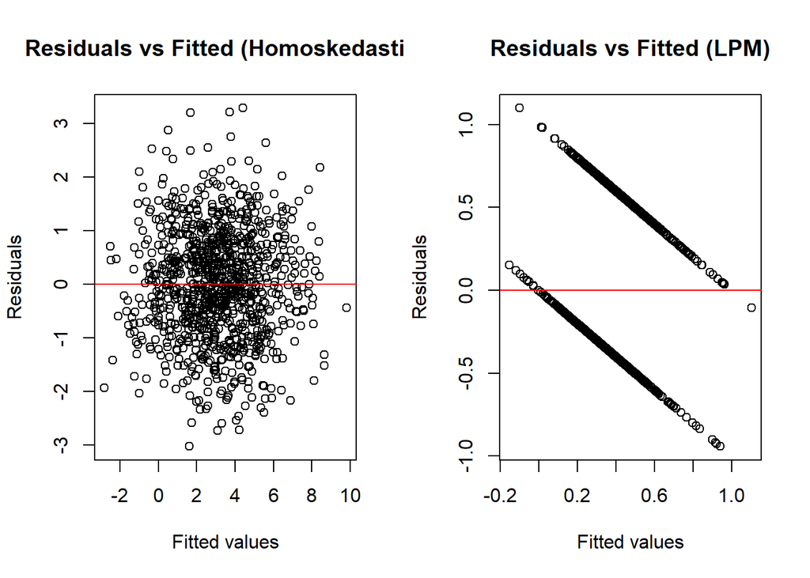

```r
# Side-by-side plots
par(mfrow = c(1, 2))

# Generate non-heteroskedastic (Homoskedastic) data for comparison
set.seed(123)

# Faux homoskedastic data
n  <- 1000
x  <- rnorm(n)
eps <- rnorm(n, mean = 0, sd = 1)   # constant variance

y  <- 3 + 2*x + eps                 # linear model with homoskedastic errors

mod <- lm(y ~ x)

# Residuals vs fitted plot
plot(
  fitted(mod),
  resid(mod),
  xlab = "Fitted values",
  ylab = "Residuals",
  main = "Residuals vs Fitted (Homoskedastic)"
)
abline(h = 0, col = "red")

# Plot residuals
plot(
  fitted(LPM),
  resid(LPM),
  xlab = "Fitted values",
  ylab = "Residuals",
  main = "Residuals vs Fitted (LPM)"
)
abline(h = 0, col = "red")
```

```r
# Calculate robust standard errors
cov_lpm <- vcovHC(LPM, type = "HC1")
robust_se <- sqrt(diag(cov_lpm))

# Present both side-by-side
stargazer(LPM, LPM,
          type = "html",
          #type = "text",
          se = list(NULL, robust_se),
          column.labels = c("Standard SEs", "Robust SEs"),
          title = "LPM: Standard vs. Robust Standard Errors",
          dep.var.labels = "Rearrested",
          covariate.labels = c("Constant",
                               "Work Program",
                               "Prior Convictions",
                               "Time Served (Months)",
                               "Felony Sentence",
                               "Alcohol Problems",
                               "Drug History",
                               "Black",
                               "Married",
                               "Education (Years)",
                               "Age (Months)",
                               "Rule Violations"),
          intercept.bottom = FALSE,
          omit.stat = c("ser", "f"),
          digits = 4)
```

**LPM: Standard vs. Robust Standard Errors**

|  | *Dependent variable:* |  |
| --- | --- | --- |
|  | Rearrested |  |
|  | Standard SEs | Robust SEs |
|  | (1) | (2) |
| Constant | 0.5167*** | 0.5167*** |
|  | (0.0735) | (0.0731) |
| Work Program | 0.0242 | 0.0242 |
|  | (0.0260) | (0.0263) |
| Prior Convictions | 0.0259*** | 0.0259*** |
|  | (0.0049) | (0.0055) |
| Time Served (Months) | 0.0032*** | 0.0032*** |
|  | (0.0008) | (0.0009) |
| Felony Sentence | -0.0867*** | -0.0867*** |
|  | (0.0309) | (0.0308) |
| Alcohol Problems | 0.1167*** | 0.1167*** |
|  | (0.0317) | (0.0325) |
| Drug History | 0.0701** | 0.0701** |
|  | (0.0291) | (0.0294) |
| Black | 0.1249*** | 0.1249*** |
|  | (0.0251) | (0.0251) |
| Married | -0.0474 | -0.0474* |
|  | (0.0293) | (0.0286) |
| Education (Years) | -0.0074 | -0.0074 |
|  | (0.0053) | (0.0050) |
| Age (Months) | -0.0007*** | -0.0007*** |
|  | (0.0001) | (0.0001) |
| Rule Violations | 0.0136** | 0.0136* |
|  | (0.0063) | (0.0072) |
| Observations | 1,445 | 1,445 |
| R<sup>2</sup> | 0.0967 | 0.0967 |
| Adjusted R<sup>2</sup> | 0.0897 | 0.0897 |
| *Note:* | p<0.1; p<0.05; p<0.01 |  |

**Instructor’s Note:**

Robust standard errors fix the heteroskedasticity problem, but they do **not** fix the other two limitations of the LPM. Those limitations are:

**1. Unbounded predictions.** The LPM can produce predicted probabilities below $0$ or above $1$. A probability of $-0.10$ or $1.15$ is meaningless.

**2. Assumed linearity.** The LPM assumes the relationship between each predictor and the probability is constant (a straight line). In reality, the relationship follows an S-curve: the effect of a variable should be largest in the middle of the probability range and shrink near the extremes ($0$ or $1$). The LPM cannot capture this non-linearity.

## Visualizing the Unboundedness Problem

Let’s check whether our LPM produces any out-of-bound predictions:

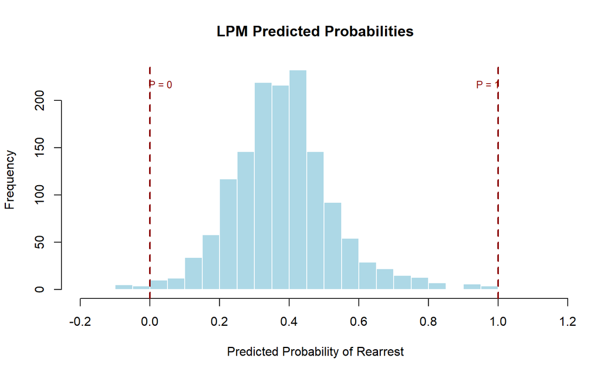

```r
# Get predicted probabilities from LPM
lpm_predicted <- predict(LPM)

# Histogram
hist(lpm_predicted,
     breaks = 30,
     main = "LPM Predicted Probabilities",
     xlab = "Predicted Probability of Rearrest",
     col = "lightblue",
     border = "white")
abline(v = 0, col = "darkred", lwd = 2, lty = 2)
abline(v = 1, col = "darkred", lwd = 2, lty = 2)
text(0.03, par("usr")[4] * 0.9, "P = 0", col = "darkred", cex = 0.8)
text(0.97, par("usr")[4] * 0.9, "P = 1", col = "darkred", cex = 0.8)
```

# The Logit Model

## Why Logit?

The logit model addresses all three limitations of the LPM:

1. **Bounded predictions:** The logistic function (S-curve) mathematically constrains all predicted probabilities to strictly fall between $0$ and $1$.
2. **Non-linear relationship:** The S-curve allows the effect of X on probability to vary, being largest in the middle and smallest at the extremes.
3. **Appropriate estimation:** The logit model uses **Maximum Likelihood Estimation (MLE)** instead of OLS, which is better suited for binary outcomes.

## Build the Logit Model

In R, we use `glm()` with `family = "binomial"` to fit a logit model:

```r
# Run the logit model
logit_model <- glm(rearrested ~ workprg + priors + tserved + felon +
                alcohol + drugs + black + married + educ + age + rules,
                   data = recid,
                   family = "binomial")

stargazer(logit_model,
          type = "html",
          #type = "text",
          title = "Logit Model: Predicting Recidivism",
          dep.var.labels = "Rearrested",
          covariate.labels = c("Constant",
                               "Work Program",
                               "Prior Convictions",
                               "Time Served (Months)",
                               "Felony Sentence",
                               "Alcohol Problems",
                               "Drug History",
                               "Black",
                               "Married",
                               "Education (Years)",
                               "Age (Months)",
                               "Rule Violations"),
          intercept.bottom = FALSE,
          omit.stat = c("ser", "f"),
          digits = 4)
```

**Logit Model: Predicting Recidivism**

|  | *Dependent variable:* |
| --- | --- |
|  | Rearrested |
| Constant | 0.2684 |
|  | (0.3592) |
| Work Program | 0.1298 |
|  | (0.1224) |
| Prior Convictions | 0.1277*** |
|  | (0.0249) |
| Time Served (Months) | 0.0153*** |
|  | (0.0039) |
| Felony Sentence | -0.4155*** |
|  | (0.1476) |
| Alcohol Problems | 0.5555*** |
|  | (0.1482) |
| Drug History | 0.3272** |
|  | (0.1354) |
| Black | 0.5882*** |
|  | (0.1182) |
| Married | -0.2173 |
|  | (0.1408) |
| Education (Years) | -0.0364 |
|  | (0.0256) |
| Age (Months) | -0.0039*** |
|  | (0.0007) |
| Rule Violations | 0.0567* |
|  | (0.0301) |
| Observations | 1,445 |
| Log Likelihood | -886.9543 |
| Akaike Inf. Crit. | 1,797.9090 |
| *Note:* | p<0.1; p<0.05; p<0.01 |

The coefficients in this table are in **log odds**. Do not interpret them as changes in probability! The `Alcohol Problems` coefficient of $0.56$ does not mean a $56\%$ increase in the probability of rearrest if you have a history of alcohol abuse. It means the log odds of rearrest increase by $0.56$. We will convert these to more meaningful units in the next section.

Also, the bottom of the table reports the **Log Likelihood** and **AIC (Akaike Information Criterion)** instead of $R^2$. These measure model fit for logit models: lower AIC and higher (less negative) log likelihood indicate better fit. You can use these to compare logit models against each other, but they are not comparable to $R^2$.

## Side-by-Side Comparison: LPM vs. Logit

```r
stargazer(LPM, logit_model,
          type = "html",
          #type = "text",
          column.labels = c("LPM", "Logit"),
          title = "Comparison: Linear Probability Model vs. Logit Model",
          dep.var.labels = "Rearrested",
          covariate.labels = c("Constant",
                               "Work Program",
                               "Prior Convictions",
                               "Time Served (Months)",
                               "Felony Sentence",
                               "Alcohol Problems",
                               "Drug History",
                               "Black",
                               "Married",
                               "Education (Years)",
                               "Age (Months)",
                               "Rule Violations"),
          intercept.bottom = FALSE,
          omit.stat = c("ser", "f"),
          digits = 4)
```

**Comparison: Linear Probability Model vs. Logit Model**

|  | *Dependent variable:* |  |
| --- | --- | --- |
|  | Rearrested |  |
|  | *OLS* | *logistic* |
|  | LPM | Logit |
|  | (1) | (2) |
| Constant | 0.5167*** | 0.2684 |
|  | (0.0735) | (0.3592) |
| Work Program | 0.0242 | 0.1298 |
|  | (0.0260) | (0.1224) |
| Prior Convictions | 0.0259*** | 0.1277*** |
|  | (0.0049) | (0.0249) |
| Time Served (Months) | 0.0032*** | 0.0153*** |
|  | (0.0008) | (0.0039) |
| Felony Sentence | -0.0867*** | -0.4155*** |
|  | (0.0309) | (0.1476) |
| Alcohol Problems | 0.1167*** | 0.5555*** |
|  | (0.0317) | (0.1482) |
| Drug History | 0.0701** | 0.3272** |
|  | (0.0291) | (0.1354) |
| Black | 0.1249*** | 0.5882*** |
|  | (0.0251) | (0.1182) |
| Married | -0.0474 | -0.2173 |
|  | (0.0293) | (0.1408) |
| Education (Years) | -0.0074 | -0.0364 |
|  | (0.0053) | (0.0256) |
| Age (Months) | -0.0007*** | -0.0039*** |
|  | (0.0001) | (0.0007) |
| Rule Violations | 0.0136** | 0.0567* |
|  | (0.0063) | (0.0301) |
| Observations | 1,445 | 1,445 |
| R<sup>2</sup> | 0.0967 |  |
| Adjusted R<sup>2</sup> | 0.0897 |  |
| Log Likelihood |  | -886.9543 |
| Akaike Inf. Crit. |  | 1,797.9090 |
| *Note:* | p<0.1; p<0.05; p<0.01 |  |

## Can You Compare These Coefficients?

**No.** The LPM coefficients are in probability units (a 1-unit change in X changes the probability by $\beta$). The logit coefficients are in log-odds units (a 1-unit change in X changes the log odds by $\beta$). These are fundamentally different scales.

What you **can** compare is the **direction** and **significance** of each variable. Both models should generally agree on whether a variable increases or decreases the likelihood of recidivism and whether that effect is statistically significant. Look across both columns: the signs and significance stars should be broadly consistent.

# Interpreting Logit Results

Now we convert the logit model’s log-odds coefficients into units that are actually interpretable: odds ratios, predicted probabilities, and discrete changes.

## Odds Ratios

To convert log-odds coefficients to odds ratios, we exponentiate them:

```r
# Odds ratios with 95% confidence intervals
exp(cbind(OR = coef(logit_model), confint(logit_model)))
```

```
##                    OR     2.5 %    97.5 %
## (Intercept) 1.3078462 0.6489719 2.6552220
## workprg     1.1386503 0.8957199 1.4478185
## priors      1.1362294 1.0833937 1.1948027
## tserved     1.0153742 1.0078053 1.0234196
## felon       0.6600010 0.4928716 0.8794809
## alcohol     1.7427925 1.3037410 2.3317145
## drugs       1.3871433 1.0633689 1.8084825
## black       1.8007606 1.4295438 2.2724982
## married     0.8046796 0.6095317 1.0590105
## educ        0.9642367 0.9169158 1.0137658
## age         0.9961274 0.9948021 0.9973957
## rules       1.0582985 0.9989177 1.1244642
```

Now that we have **odds ratios**, we have our ‘multiple’. **Quick check in: What are the constraints of odds ratios? Do you remember?** – 5 – 4 – 3 – 2 – 1 – 0.5 – Answer Below…

$0$ to $+\infty$; where $1$ = No Change. Anything over $1$ is an increased odds of $Y$ happening and anything less than $1$ is a decreased odds.

Take a look at the confidence intervals. Normally our confidence intervals, if they cross $0$, they would not be significant at the $p < 0.05$ level; however, because $1$ is our “No Effect” boundary, if the spread between $2.5\%$ and $97.5\%$ includes $1$, our coefficient would not be significant at the $p < 0.05$ level.

Let’s discuss a few of these results.

`workprg` = $1.14$

- Participating in a work program increases the odds of recidivism by $1.14x$, where $x$ is the unknown baseline. But, the $95\%$ confidence interval crosses $1$, therefore no statistically significant impact of work programs on recidivism.

`alcohol` = $1.74$

- Having a history of alcohol use increases the odds of recidivism. by $1.7x$, again, $x$ is an unknown baseline. The confidence intervals for `alcohol` range from $1.3$ to $2.3$, indicating we are $95\%$ confident that the true effect lies within that range.

**Bottom line of Odds Ratios:** These are important but not so much meaningful in terms of realistic inference.

## Predicted Probabilities

Odds ratios have their use cases, but probabilities are the most intuitive way to communicate logit results. We can calculate predicted probabilities for specific scenarios using the manual approach (Probability Formula) or the modern approach using `predict(...type = "response")`. We will demonstrate both.

### Method 1: The Probability Formula Manual Approach)

$$P(Y=1) = \frac{1}{1 + e^{-(\beta_0 +
\beta_1 X_1 + \beta_2 X_2 + \cdots)}}$$

Let’s calculate the probability of rearrest for an “average” individual:

```r
# Get the means of each variable
mean_workprg <- mean(recid$workprg)
mean_priors <- mean(recid$priors)
mean_tserved <- mean(recid$tserved)
mean_felon <- mean(recid$felon)
mean_alcohol <- mean(recid$alcohol)
mean_drugs <- mean(recid$drugs)
mean_black <- mean(recid$black)
mean_married <- mean(recid$married)
mean_educ <- mean(recid$educ)
mean_age <- mean(recid$age)
mean_rules <- mean(recid$rules)

# The "average" person at mean values of all variables
data.frame(mean_workprg, mean_priors, mean_tserved, mean_felon, mean_alcohol, mean_drugs, mean_black, mean_married, mean_educ, mean_age, mean_rules)
```

```
##   mean_workprg mean_priors mean_tserved mean_felon mean_alcohol mean_drugs mean_black mean_married mean_educ mean_age
## 1    0.4650519    1.431834     19.18201  0.3141869    0.2096886  0.2415225  0.4851211    0.2553633  9.702422  345.436
##   mean_rules
## 1   1.185467
```

```r
# Extract coefficients
b <- coef(logit_model)

# Calculate log odds manually
log_odds_avg <- b[1] + b[2]*mean_workprg + b[3]*mean_priors + b[4]*mean_tserved +
                b[5]*mean_felon + b[6]*mean_alcohol + b[7]*mean_drugs + b[8]*mean_black + b[9]*mean_married +
                b[10]*mean_educ + b[11]*mean_age + b[12]*mean_rules

# Convert to probability
prob_avg <- 1 / (1 + exp(-log_odds_avg))

cat("The 'average' person's probability to recidivate =", 100*round(prob_avg,4), "%\n")
```

```
## The 'average' person's probability to recidivate = 37.11 %
```

### Method 2: Using `predict()` (Recommended)

The `predict()` function does the same calculation automatically. This is the method you should use in practice:

```r
# Create a data frame with average values
avg_person <- data.frame(
  workprg = mean(recid$workprg),
  priors = mean(recid$priors),
  tserved = mean(recid$tserved),
  felon = mean(recid$felon),
  alcohol = mean(recid$alcohol),
  drugs = mean(recid$drugs),
  black = mean(recid$black),
  married = mean(recid$married),
  educ = mean(recid$educ),
  age = mean(recid$age),
  rules = mean(recid$rules)
)

# Predict probability (type = "response" gives probabilities, not log odds)
prob_avg_predict <- predict(logit_model, newdata = avg_person, type = "response")

cat("Predicted probability (via predict) =", 100 * round(prob_avg_predict, 4), "%\n")
```

```
## Predicted probability (via predict) = 37.11 %
```

**Instructor’s Note:**

The `type = "response"` argument is critical. Without it, `predict()` returns the **log odds** (the linear combination $\beta_0 + \beta_1 X_1 + \cdots$), not the probability. Always include `type = "response"` when you want predicted probabilities from a logit model.

## Discrete Changes

A discrete change is the difference in predicted probability between two scenarios. This is a powerful way to communicate logit results.

### Example: Effect of Drug History

How much does drug history change the predicted probability of rearrest, for an otherwise “average” person?

```r
# Scenario 1: Average person WITHOUT drug history
no_drugs <- avg_person
no_drugs$drugs <- 0

# Scenario 2: Average person WITH drug history
has_drugs <- avg_person
has_drugs$drugs <- 1

# Predict both
prob_no_drugs <- predict(logit_model, newdata = no_drugs, type = "response")
prob_has_drugs <- predict(logit_model, newdata = has_drugs, type = "response")
discrete_change <- prob_has_drugs - prob_no_drugs

cat(
  "Probability of rearrest (no drug history):", 100 * round(prob_no_drugs, 4), "%\n",
  "Probability of rearrest (drug history):   ", 100 * round(prob_has_drugs, 4), "%\n",
  "Discrete change:                          ", 100 * round(discrete_change, 4), "%\n"
)
```

```
## Probability of rearrest (no drug history): 35.29 %
##  Probability of rearrest (drug history):    43.07 %
##  Discrete change:                           7.78 %
```

### Example: Effect of Moving from Mean to 95th Percentile in Prior Convictions

```r
# Scenario 1: Average person at mean priors
mean_priors_person <- avg_person

# Scenario 2: Average person at 95th percentile of priors
high_priors_person <- avg_person
high_priors_person$priors <- quantile(recid$priors, 0.95)

# Predict both
prob_mean_priors <- predict(logit_model, newdata = mean_priors_person, type = "response")
prob_high_priors <- predict(logit_model, newdata = high_priors_person, type = "response")

discrete_change_priors <- prob_high_priors - prob_mean_priors

cat(
  "95th percentile of prior convictions:", quantile(recid$priors, 0.95), "\n",
  "Mean prior convictions:", round(mean(recid$priors), 2), "\n\n",
  "Probability at mean priors:     ", 100 * round(prob_mean_priors, 4), "%\n",
  "Probability at 95th %ile priors:", 100 * round(prob_high_priors, 4), "%\n",
  "Discrete change:                ", 100 * round(discrete_change_priors, 4), "%\n"
)
```

```
## 95th percentile of prior convictions: 7
##  Mean prior convictions: 1.43
##
##  Probability at mean priors:      37.11 %
##  Probability at 95th %ile priors: 54.58 %
##  Discrete change:                 17.47 %
```

## Plotting the S-Curve

One of the best ways to understand the logit model is to visualize the S-curve — how the predicted probability changes as one variable varies while all others are held at their means.

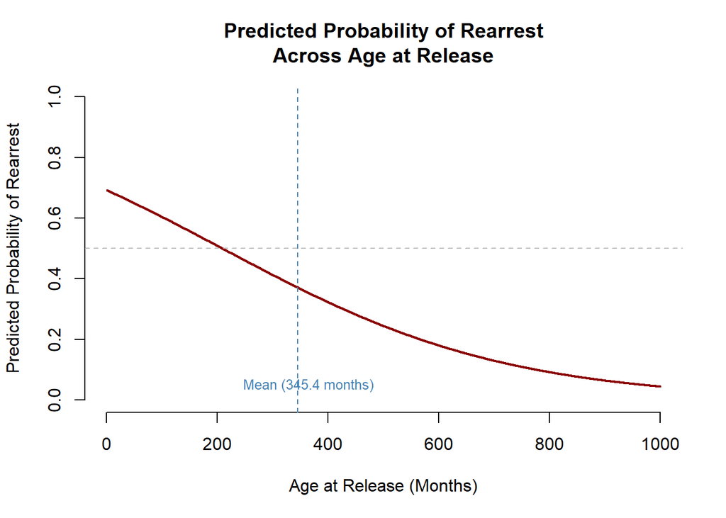

```r
# Create prediction data: vary age (in months), hold everything else at mean
plot_data_age <- data.frame(
  workprg = mean(recid$workprg),
  priors = mean(recid$priors),
  tserved = mean(recid$tserved),
  felon = mean(recid$felon),
  alcohol = mean(recid$alcohol),
  drugs = mean(recid$drugs),
  black = mean(recid$black),
  married = mean(recid$married),
  educ = mean(recid$educ),
  age = seq(1, 1000, by = 1),
  rules = mean(recid$rules)
)


# Predict probabilities
plot_data_age$predicted_prob <- predict(logit_model, newdata = plot_data_age, type = "response")

# Plot
plot(plot_data_age$age, plot_data_age$predicted_prob,
     type = "l", lwd = 2, col = "darkred",
     xlab = "Age at Release (Months)",
     ylab = "Predicted Probability of Rearrest",
     main = "Predicted Probability of Rearrest\nAcross Age at Release",
     bty = "n",
     ylim = c(0, 1))

# Add reference lines
abline(h = 0.5, lty = 2, col = "gray")
abline(v = mean(recid$age), lty = 2, col = "steelblue")
text(mean(recid$age) + 20, 0.05,
     paste0("Mean (", round(mean(recid$age), 1), " months)"),
     col = "steelblue", cex = 0.8)
```

Not the typical S-curve you expected? The logit model shapes an S-curve but our data may only sit on **part** of that curve. We can still see that the steepest part of the curve is at a Probability of $0.5$.

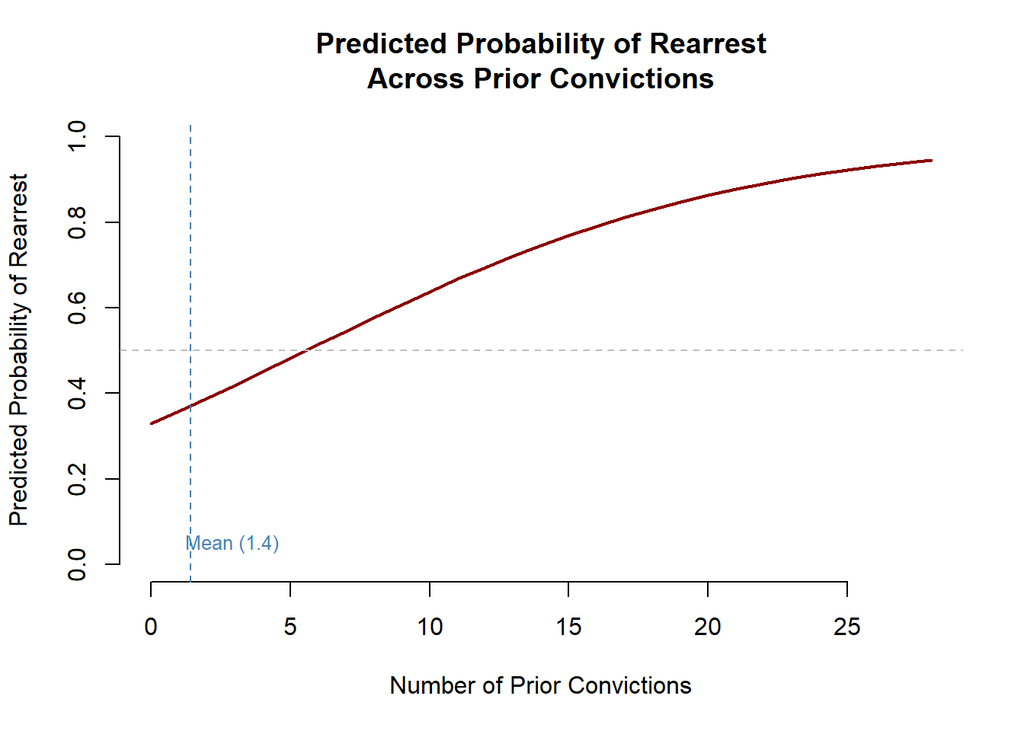

```r
# Create prediction data: vary prior convictions, hold everything else at mean
plot_data_priors <- data.frame(
  workprg = mean(recid$workprg),
  priors = seq(0, max(recid$priors), by = 1),
  tserved = mean(recid$tserved),
  felon = mean(recid$felon),
  alcohol = mean(recid$alcohol),
  drugs = mean(recid$drugs),
  black = mean(recid$black),
  married = mean(recid$married),
  educ = mean(recid$educ),
  age = mean(recid$age),
  rules = mean(recid$rules)
)

# Predict probabilities
plot_data_priors$predicted_prob <- predict(logit_model, newdata = plot_data_priors, type = "response")

# Plot
plot(plot_data_priors$priors, plot_data_priors$predicted_prob,
     type = "l", lwd = 2, col = "darkred",
     xlab = "Number of Prior Convictions",
     ylab = "Predicted Probability of Rearrest",
     main = "Predicted Probability of Rearrest\nAcross Prior Convictions",
     bty = "n",
     ylim = c(0, 1))

# Add reference lines
abline(h = 0.5, lty = 2, col = "gray")
abline(v = mean(recid$priors), lty = 2, col = "steelblue")
text(mean(recid$priors) + 1.5, 0.05,
     paste0("Mean (", round(mean(recid$priors), 1), ")"),
     col = "steelblue", cex = 0.8)
```

As the number of prior convictions increases, the predicted probability of rearrest increases before leveling off. At $\approx5$ prior convictions, the slope is the steepest, meaning that one less prior or one additional prior has a greater effect on the probability of rearrest than going from $20$ to $21$ priors. Notice again that our S-shape exists, but our data doesn’t fit the entire curve? This is going to be normal. Don’t be concerned if you find this in your own work. Data doesn’t necessarily match the typical S-shape.

# Marginal Effects

## Why Marginal Effects?

The `margins()` function from the `margins` package calculates marginal effects for us.

## Average Marginal Effects (AME)

The **average marginal effect** calculates the marginal effect for every observation in the dataset and then takes the average. It answers: *“On average across all individuals, how much does a 1-unit change in X change the probability?”*

```r
# Calculate average marginal effects
m <- margins(logit_model)

summary(m)
```

```
##   factor     AME     SE       z      p   lower   upper
##      age -0.0008 0.0001 -6.0871 0.0000 -0.0011 -0.0006
##  alcohol  0.1182 0.0310  3.8151 0.0001  0.0575  0.1790
##    black  0.1252 0.0244  5.1355 0.0000  0.0774  0.1730
##    drugs  0.0697 0.0286  2.4351 0.0149  0.0136  0.1257
##     educ -0.0078 0.0054 -1.4264 0.1537 -0.0184  0.0029
##    felon -0.0885 0.0311 -2.8425 0.0045 -0.1494 -0.0275
##  married -0.0463 0.0299 -1.5478 0.1217 -0.1048  0.0123
##   priors  0.0272 0.0051  5.2920 0.0000  0.0171  0.0373
##    rules  0.0121 0.0064  1.8933 0.0583 -0.0004  0.0245
##  tserved  0.0032 0.0008  3.9756 0.0001  0.0016  0.0048
##  workprg  0.0276 0.0260  1.0618 0.2883 -0.0234  0.0787
```

A few important things to discuss here. First, the `Average Marginal Effect` calculates the change in probability for every person in our dataset, then averages those changes.

`age` has a statistically significant AME at the $p < 0.001$ level. For every month increase in age, the probability of rearrest decreases by $0.0008$ (or $0.08$ percentage points). For every additional year the probability of being arrested goes down $\approx1\%$.

`drugs` has a statistically significant AME at the $p < 0.05$ level. Having a history of drug abuse increases the average probability of rearrest by $0.0697$ (or $\approx 7$ percentage points). This is a meaningful result.

`tserved` has a statistically significant AME at the $p < 0.001$ level. For every additional month served in prison, the probability of rearrest increases by $0.0032$ (or $0.32$ percentage points). Like `age`, this per-month effect may appear small, but every additional year of time served increases the probability of recidivism by nearly $4$ percentage points.

Average marginal effects from the logit model are the closest analog to LPM coefficients. Both represent the “average” effect of a 1-unit change on probability. You can compare AMEs to LPM coefficients to check whether the two models tell a broadly similar story.

## Marginal Effects at Specific Values

Sometimes we care about the marginal effect at a particular point, not the average across all observations. For instance, does an additional year of age have a bigger effect on someone who is 20 or someone who is 40?

```r
# Marginal effect of age at 20 years
me_age_20 <- margins(logit_model, at = list(age  = 240), variables = "age")

# Marginal effect of age at 40 years
me_age_40 <- margins(logit_model, at = list(age  = 480), variables = "age")

rbind(summary(me_age_20), summary(me_age_40))
```

```
##  factor      age     AME     SE       z      p   lower   upper
##     age 240.0000 -0.0009 0.0001 -5.8577 0.0000 -0.0012 -0.0006
##     age 480.0000 -0.0007 0.0001 -7.7541 0.0000 -0.0009 -0.0005
```

Let’s do the same for prior convictions. Does an additional prior conviction have a bigger effect on someone with $8$ prior or someone with $25$ priors?

```r
# Marginal effect of priors at 8 prior conviction
me_priors_1 <- margins(logit_model, at = list(priors = 8), variables = "priors")

# Marginal effect of priors at 25 prior convictions
me_priors_8 <- margins(logit_model, at = list(priors = 25), variables = "priors")

rbind(summary(me_priors_1), summary(me_priors_8))
```

```
##  factor  priors    AME     SE      z      p  lower  upper
##  priors  8.0000 0.0285 0.0049 5.8543 0.0000 0.0190 0.0380
##  priors 25.0000 0.0101 0.0025 4.0697 0.0000 0.0052 0.0149
```

The marginal effects differ because of the non-linear S-shape. At different starting points along the probability curve, the slope is different, and therefore the same 1-unit change produces a different absolute change in probability. This is a fundamental property of logistic regression.

**Instructor’s Note: Heads up for your lab**

In your lab you will be asked a similar question. In the case of this lab, there are plenty of arguments one could make as to why one group or the other should be targeted where the rationale is derived from more than just the absolute value of the average marginal effect, and that is great. The point of this exercise is to demonstrate how to use marginal effects to inform policy decisions as part of a holistic analysis. The **answer** for your lab is less nuanced and you should strongly consider the absolute impact and how the slope changes on the S-curve when making your decision.